# Quantitative Genetics

Covariance Between Relatives

Felipe Ferrão

University of Florida

**Objectives:**

- 60 minutes of hands-on
- Introduction to Covariance between relative
- Create a file to compute a relationship matrix
- Use mixed model to combine theory on resemble between relatives and inference on genetic parameters

**Extra information**

- [PCB 65555 – Website](https://lfelipe-ferrao.github.io/class/quantGenetic/)
- About the [author](https://lfelipe-ferrao.github.io/)
- About the [UF/IFAS Plant Breeding](https://programs.ifas.ufl.edu/plant-breeding/)

# Introduction

In the last topic we derived the equations for calculating the total genetic variance and the additive and dominance components. This section is one of the most important in quantitative genetics because we will connect concepts related to experimental statistics, breeding, population genetics and quantitative genetics. Main goal here is to understand how the knowledge on variance and covariance in structure populations can be used to estimate the additive and dominance portion of the genotypic variance.

Given the importance of connecting theory with practice, resemblance between relatives has been treated as the **central dogma of the quantitative genetics** and can be used to estimate genetic components in a given population. An important concept is that, step-by-step, we are translating some theoretical concepts related to additive and non-additive source of genetic variations into real context.

Below, we can see a seminal paper presented by Fisher presenting such ideas.

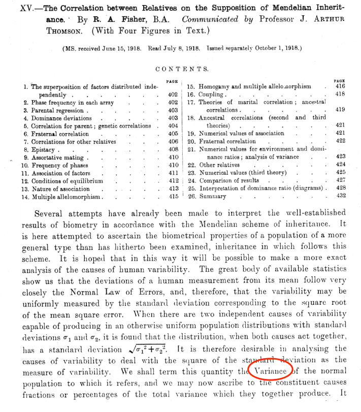

**How to estimate genetic variance**

1. Relative developed by some sort of mating design (**breeding**)
2. Progenies are phenotyped for target traits (**breeding**)
3. Variance components are estimated via ANOVA (**statistics**)
4. Variance components are interpreted in terms of the covariances between relatives (**genetics**)

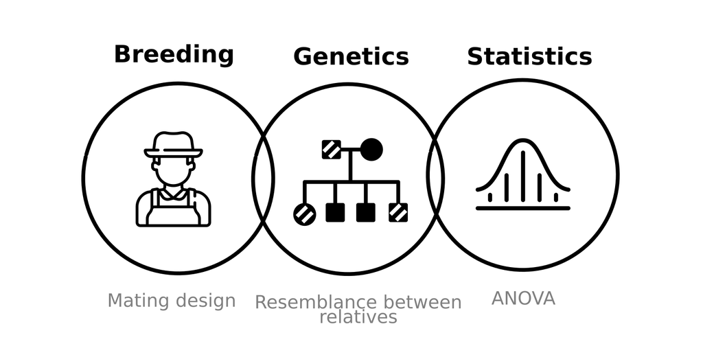

# Theory

## Simple deduction, powerful conclusions

**The genetic covariance between genotypes within the families, is the same of the genetic variance between families**

$$Y_{ij} = \mu + g_i + e_{ij}$$

$$cov(Y_{ij},Y_{ij'}) = cov(\mu + g_i
+ e_{ij'},\mu + g_i + e_{ij'})$$

$$= cov(g_i,g_i)+cov(g_i+eij) +
cov(e_{ij},e_{ij'}) = \sigma^2_g$$

**Why this is so important?**

1. Breeders can derive families from a target population and design experiments using all the properties from experimental statistics (randomization, repetition and local control – when necessary).
2. We fit an ANOVA model to decompose the variance into source of variations.
3. We can estimate the $\sigma^2_g$, that in a statistical framework is a variance between the family means.
4. As breeders/geneticist if we know the population structure, the variance between families is equal to the covariance within families. Therefore, we know how to translate the genetic variance (that is natural output from any ANOVA method) into additive variances.
5. By combining statistical and genetics we can finally **estimate the additive genetic variance** using breeding trials.

Below, a very simple representation:

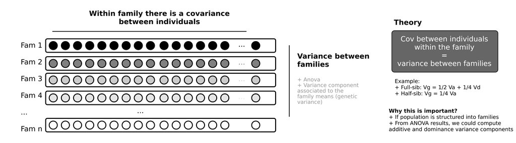

Simple representation for the main idea from this class. We will assume a population structured into families, with n individuals per family. We can separate it into two statistical variations. Covariance within family and variance between families

## Breeding

A mating design is a systematic method of developing progeny. There are different forms:

- Half-sib design: random mating of each of males to different females and evaluation of a offspring from each female. It is straightforward to be implemented, because we don’t need to know who are the males, but genetic inference is restricted to additive variance.
- Full-sib design: selected males are each mated to several females and several offspring are assayed per family. The use of controlled crosses created more labor, but with the advantage that we can estimate additive and dominance variances.
- North Carolina Design I: it includes both full-sibs and half-sibs, since each male is mated to different set of females and the offsprings are evaluated. Described by Comstock and Robinson (1948), both additive and dominance effects can be computed separately.
- North Carolina Design II: factorial design, parents are divided into a male group and a female group. Both additive and dominance effects can be computed separately, but with more statistical power.
- Diallel: a group of parents are crossed to itself. We can estimate additive, dominance and make inference about heterosis by selecting parents with good general combining ability (GCA) and hybrids with good specific combining ability (SGA).

## Resemblance between relatives

The **covariance** between two random variables is a measure of how much they vary together— covary.

For example, if the covariance is large and positive, they tend to vary in the same way. On the other hand, if the covariance is small, it means there isn’t a strong tendency for deviations from the mean in one variable to be associated with deviations in the other.

$$Cov(X,Y) = \sum p_{xy} (x_i-\mu_x)
(y_i-\mu_y)$$

There are different ways to calculate the covariance between relative. Below, a summary of expected covariance in genotypic values between groups of relatives and how to compute the covariance between relatives using covariance properties or the general method:

- Offspring - One parent: 1/2 Va
- Half-sibs: 1/4 Va
- Full-sibs: 1/2 Va + 1/4Vd
- Nephew - Uncle: 1/4 Va
- First cousins: 1/8 Va
- Monozygotic twins: Va + Vd

### Covariance

Deriving this covariance relies on a mathematical property of the covariance. Specifically, we can expand the covariance equation according to genotypic means and show how is the **resemble between parent and offspring:**

|  | Parent |  |  |  | Offspring |  |  |
| --- | --- | --- | --- | --- | --- | --- | --- |
| Genotype | Freq | Genotypic Value | A1A1 | A1A2 | A2A2 | Mean Value | Mean Value - Pop.Mean |
| A1A1 | $p^2$ | $2q-(\alpha - qd)$ | p | q | - | $pa -qd$ | $q\alpha$ |
| A1A2 | 2pq | $(q-p)\alpha + 2pqd$ | p/2 | 1/2 | q/2 | $1/2[a(p-q)+d]$ | $1/2(q-p) \alpha$ |
| A2A2 | $q^2$ | $-2p( α + pd)$ | - | p | q | $pd-qa$ | $-p\alpha$ |

where `Pop.Mean` = $a(p-1)+2pqd$

Assuming that all values are centered on the mean, the covariance equation can be simplified as: $Cov(X,Y) = \sum p_{xy} (x_iy_i)$ and the covariance between a parent and the offspring can be computed with a bit of algebra:

$$\begin{align*}
COV(P,O) = p^2 [2q(\alpha-qd).q\alpha] + 2pq[(q-p) \alpha + 2pqd] .
[1/2(q-p) \alpha] + q^2 [-2p(\alpha + pd) . (-p\alpha)]\\
= 2p^2 q^2 \alpha^2 - 2p^2 q^3 d\alpha + pq^3 \alpha^2 - p^2 q^2
\alpha^2 - p^2 q^2 \alpha^2 + p^3 q\alpha^2 + 2p^2 q^3 d\alpha - 2p^3
q^2 d\alpha + 2p^2 q^2 \alpha^2 + 2p^3 q^2 d\alpha\\
= pq^3 \alpha^2 + p^3 q \alpha^2 + 2p^2 q^2 \alpha^2\\
= pq\alpha^2 (q^2 + p^2 + 2pq)\\
= pq\alpha^2 \\
= \dfrac{1}{2} V_A\\
\end{align*}$$

Same logic can be used for full and half-siblings families

### General Method

The expected covariance in genotypic values in pedigrees can also be computed using the general method, as proposed by Cotterman (1974,1983) and Crow and Kimura (1970); by separating the additive and dominance variances

$$Cov(X,Y) = rV_A + uV_D$$

$$Cov(X,Y) = 2\theta_{XY}V_A +
\Delta_{xy}V_D$$

where:

- r = $2f_{xy}$ or $2\theta_{XY}$. The $r$ coefficient is twice the probability that individuals *x* and *y* inherit an allele that is identical by descent. The $r$ is also called the *coefficient of relationship* or *kinship* or *coancestry* and can be seen as the correlation between the breeding values.
- u = $f_{AC}f_{BD}+f_{AD}f_{BC}$ or $\Delta_{xy}$. The $u$ coefficient is the probability that individuals *x* and *y* inherit the same genotype. The probability of inheriting the same genotype depends on the probability that both alleles in the genotypes of $x$ and $y$ are identical by descent. This is why the $u$ term is not null when covariance between full-sibs is considered – in a full-sib family, there is a probability of one-quarter of all sib-pairs have the same genotype.

**Example of full-sib**

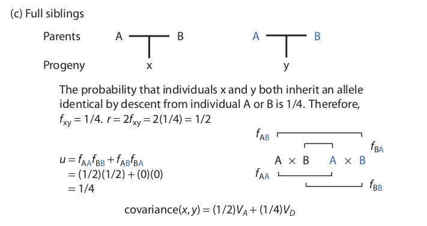

Example from Hamilton, (2009)

## Statistics

In the sequence we will present a numerical example, based on ANOVA results how we can connect the resemble between relatives and estimate genetic parameters. Please, keep in mind the following three main goals:

- We know how to partition the variances using ANOVA.
- We also know how to design progeny tests using breeding methods
- We can combine both information to estimate genetic parameters

### ANOVA (Desing I)

Also knows as Noth Carolina Desing I, it was a classical design proposed by Comstock and Robinson (1948). It is one of the most common designs used in maize, since it is easy to produce a large number of progenies and can be used to estimate variance components associated to additive and dominance effects. The design is describe in the sequence, but it combines information from half and full-sib populations.

Mate a number of males (sires) with a number of females (dams). Each sire is mated to more than one dam, but each dam mates only with one sire. This design is called nested paternal half-sibling design:

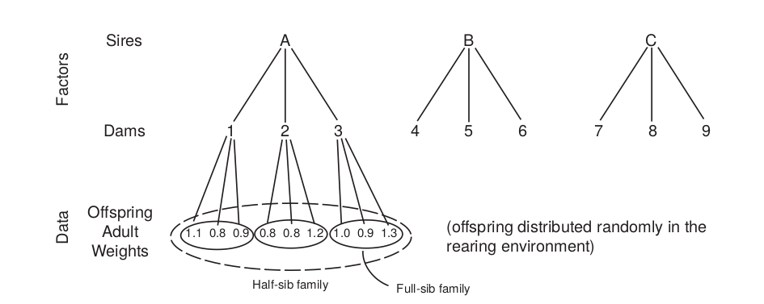

We can perform an ANOVA on the phenotype in the progeny, treating sire and dam as main effects. The offspring of each dam represent full-sibling families (because they have the same mother and father), and these are nested within half-sibling families, that is, all the offspring of the same father. The variance **among half-sibling families** can be used to estimate $V_A$.

$$y_{ijk} = \mu + m_i + f_{ij} +
e_{ijk}$$

where $m_i$ is the effect of the male (sires), $f_{ij}$ is the effect of females (dams) mated to the males (sires).

| Source | d.f. | Mean square | Composition |
| --- | --- | --- | --- |
| Among sires | $s-1$ | $MS_s$ | $\sigma^2_W + k\sigma^2_D + dk\sigma^2_s$ |
| Among dams (within sires) | $s(d-1)$ | $MS_D$ | $\sigma^2_W + k\sigma^2_D$ |
| Within progenies | $sd(k-1)$ | $MS_W$ | $\sigma^2_W$ |

Now we need some way to relate the variance components ($\sigma^2_W, \sigma^2_D, \sigma^2_S$)to $V_A$, $V_D$, and $V_E$. This could be done using the results from the resemblance between relatives. for example:

$$V_P = \sigma^2_{total} = \sigma^2_S +
\sigma^2_D + \sigma^2_W$$
where $\sigma^2_S$ estimates the variance among the means of the half-sib familes fathered by each of the different sires or, equivalently, the covariance among half-sib or

$$\sigma^2_S = Cov_{HS} =
\dfrac{1}{4}V_A$$
In the sequence, we can consider the within progeny component of the variance, $\sigma^2_W$. In general, it can be shown that any among group variance component is equal to the covariance among the members within the groups. Thus, a within group component of the variance is equal to the total variance minus the covariance within groups. In this case,

$$\begin{align*}
\sigma^2_W= V_P - Cov_{FS}\\
= V_A + V_D + V_E -[1/2 V_A + 1/4 V_D]\\
= \dfrac{1}{2} V_A + \dfrac{3}{4} V_D + V_E \\
\end{align*}$$

From here, it remains only $\sigma^2_D$. Now, $\sigma^2_W = V_P - Cov_{FS}$, $\sigma^2_S = Cov_{HS}$ and $\sigma^2_T=V_P$. Thus,

$$\begin{align*}
\sigma^2_D= \sigma^2_T - \sigma^2_S - \sigma^2_W \\
= V_P - Cov_{HS} - (V_P - Cov_{FS})\\
= Cov_{FS} - Cov_{HS} \\
= [1/2 V_A + 1/4 V_D] - 1/4 V_A\\
= \dfrac{1}{4} V_A + \dfrac{1}{4} V_D\\
\end{align*}$$

So if we rearrange these equations, we can express the genetic components of the pheno- typic variance, the causal components of variance, as simple functions of the observational components of variance:

$$V_A = 4\sigma^2_S$$
$$V_D = 4(\sigma^2_D-\sigma^2_S)$$
$$V_E = \sigma^2_W- 3\sigma^2_D +
\sigma^2_S$$

$$h^2 = \dfrac{4\sigma^2_S}{\sigma^2_S +
\sigma^2_D + \sigma^2_W}$$

### Numerical Example

Step-by-step when using ANOVA methods.

1. Create an experimental design using family structure
2. Estimate the variance components using the Method of Moments
3. From the knowledge of the relationship between kinship, from the results of ANOVA, it is possible to estimate $V_A$ and $h^2$.

**Nested paternal half-sibling design**

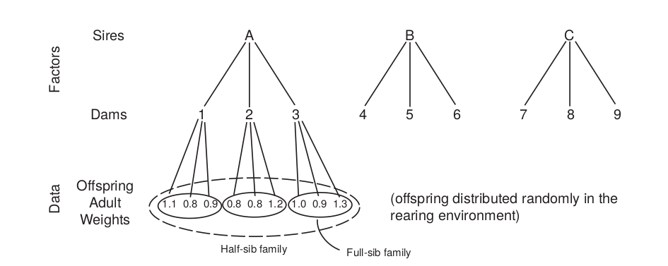

Example of Nested paternal half-sibling design

**ANOVA table**

| Source | d.f. | Mean square | Composition |
| --- | --- | --- | --- |
| Among sires | $s-1$ | $MS_s$ | $\sigma^2_W + k\sigma^2_D + dk\sigma^2_s$ |
| Among dams (within sires) | $s(d-1)$ | $MS_D$ | $\sigma^2_W + k\sigma^2_D$ |
| Within progenies | $sd(k-1)$ | $MS_W$ | $\sigma^2_W$ |

$$V_A = 4\sigma^2_S$$
$$V_D = 4(\sigma^2_D-\sigma^2_S)$$
$$V_E = \sigma^2_W- 3\sigma^2_D +
\sigma^2_S$$
$$h^2 =
\dfrac{4\sigma^2_S}{\sigma^2_S + \sigma^2_D + \sigma^2_W}$$

**Numerical Example**

- Example from from Falconer and Mackay.
- 719 offspring from 74 sires and 192 dams, each with one litter.

[output not shown]

d = 2.33; k=3.48 ; k’= 4.16

- $\sigma^2_W = MS_W = 2.19$
- $\sigma^2_D = (1/k) (MS_D - \sigma^2_W) = 2.47$
- $\sigma^2_S = (1/dk') (MS_S - \sigma^2_W - k'\sigma^2_D) =0.48$

Thus,

- $V_P = \sigma^2_S + \sigma^2_D + \sigma^2_W = 5.14$
- $V_A = 4 \sigma^2_S = 1.92$
- $h^2 = \dfrac{V_A}{V_P} = 0.37$

# Hands-on

**Exercise**

- Check the pedigree presented.
- By hand, create a pedigree matrix between all the 14 individuals
- Check the tutorial of the `AGHmatrix` and create a text file containing the pedigree information required for computing a relationship matrix
- Using the `AGHmatrix` compute the A matrix

## Computing a relationship matrix

- [Tutorial AGHmatrix](https://cran.r-project.org/web/packages/AGHmatrix/vignettes/Tutorial_AGHmatrix.html)

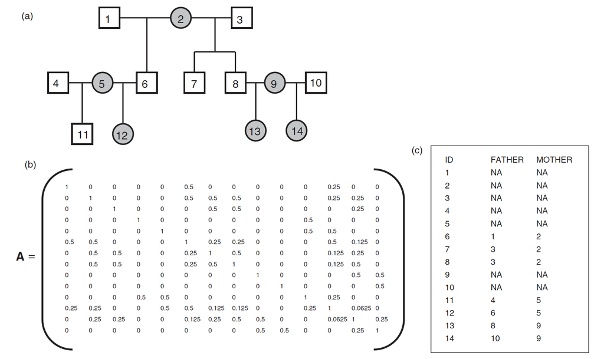

```r
library(AGHmatrix)
# Recording the data
## Important: AGHmatrix record unknown pedigree as 0 (zero) not as NA
ped =data.frame(ID=c(1:14),
           FATHER=c(0,0,0,0,0,1,3,3,0,0,4,6,8,10),
           MOTHER=c(0,0,0,0,0,2,2,2,0,0,5,5,9,9))
ped$ID=as.factor(ped$ID) # Transform into factors
ped$FATHER=as.factor(ped$FATHER)
ped$MOTHER=as.factor(ped$MOTHER)

# Running the package
Aped = Amatrix(ped, ploidy=2)
```

```
## Verifying conflicting data...
## Organizing data...
## Your data was chronologically organized with success.
## Constructing matrix A using ploidy = 2
## Completed! Time = 0  minutes
```

```r
Aped[1:9,1:9]
```

```
##     1   2   3 4 5    6    7    8 9
## 1 1.0 0.0 0.0 0 0 0.50 0.00 0.00 0
## 2 0.0 1.0 0.0 0 0 0.50 0.50 0.50 0
## 3 0.0 0.0 1.0 0 0 0.00 0.50 0.50 0
## 4 0.0 0.0 0.0 1 0 0.00 0.00 0.00 0
## 5 0.0 0.0 0.0 0 1 0.00 0.00 0.00 0
## 6 0.5 0.5 0.0 0 0 1.00 0.25 0.25 0
## 7 0.0 0.5 0.5 0 0 0.25 1.00 0.50 0
## 8 0.0 0.5 0.5 0 0 0.25 0.50 1.00 0
## 9 0.0 0.0 0.0 0 0 0.00 0.00 0.00 1
```

## Family Models

### Half-sib model

In this class we will compute genetic parameters using a half-sib population. Central goal here is to understand how breeding, statistics and genetics are connected. Some comments:

- There are multiple ways to estimate variance components and breeding values from progeny test data.
- In some cases, we might be interested in **parental breeding values**.
- Parental models based on half-sibs (also called GCA model) may be preferred, because it it is straightforward to fit.

**Example**

The objective is to **rank the female parents for future selections and seed production**.

**Postulating a Mixed Model**

$$y_{ij} = \mu + B_i + \underline{F_j} +
\underline{e_{ij}}$$

- $\mu$ is the overall mean;
- $B_i$ = effect of block i
- $F_j$ = random effect of female j, where $F_{j} \sim N(0, I\sigma^2_g)$
- $e_{ij}$ = random effect error, distributed as: $e_{ijk} \sim N(0, I\sigma^2_e)$

OBS: depending on the experimental desing the linea model can change. In this case, we have multiple female observation per plot within block, therefore we could test the interaction (or create a explicit plot effect in the model). In the case of single-tree plots (for example, when an average value per plot is measured) we should drop the “plot effect” from the model.

```r
library(asreml)
library(dplyr)
library(openxlsx)

###############################
## Sire Model (Female)
###############################
setwd("/home/felipe/Dropbox (UFL)/classes/QuantGen_24/Class6_Covariance")
# Download the factor
coffee = read.xlsx("./coffee_mean.xlsx")
head(coffee)
```

```
##   mother block BeanWeight_g
## 1    104     1     24.47143
## 2    104     2     25.92143
## 3    104     3     25.15000
## 4    105     1     15.74286
## 5    105     2     18.12857
## 6    105     3     18.10714
```

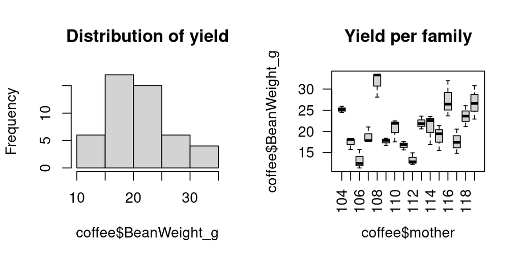

```r
coffee$mother= as.factor(coffee$mother)
coffee$block= as.factor(coffee$block)

# Visual inspection
par(mfrow=c(1,2))
hist(coffee$BeanWeight_g, main="Distribution of yield")
boxplot(coffee$BeanWeight_g~coffee$mother, las=2, main= "Yield per family")
```

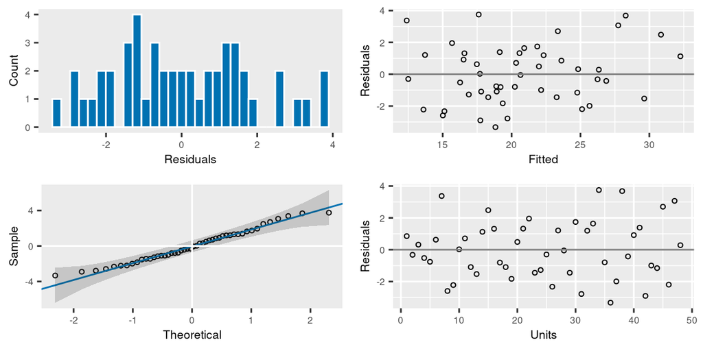

```r
# Fitting Sire/Female model
# y = m + block + !female + !e
mF<-asreml(fixed=BeanWeight_g~block,
           random=~mother,
           data=coffee)
plot(mF)
```

```r
summary(mF)$varcomp
```

```
##         component std.error  z.ratio bound %ch
## mother   24.65431  9.624649 2.561580     P   0
## units!R   5.03232  1.299341 3.872979     P   0
```

```r
# Inference Fixed Effect
wald.asreml(mF) # More similar to the regular anova
```

```
## Wald tests for fixed effects.
## Response: BeanWeight_g
## Terms added sequentially; adjusted for those above.
##
##               Df Sum of Sq Wald statistic Pr(Chisq)
## (Intercept)    1   1313.42        260.996 < 2.2e-16 ***
## block          2     55.21         10.971  0.004147 **
## residual (MS)         5.03
## ---
## Signif. codes:  0 '***' 0.001 '**' 0.01 '*' 0.05 '.' 0.1 ' ' 1
```

```r
# Inference Random Effects
adj.mean = predict(mF,classify='mother')$pvals # adjusted mean (original scale)

# Ranking
library(dplyr)
as.data.frame(adj.mean) %>%
  arrange(desc(predicted.value)) %>%
  head()
```

```
##   mother predicted.value std.error    status
## 1    108        30.91034  1.255888 Estimable
## 2    116        26.93837  1.255888 Estimable
## 3    119        26.39740  1.255888 Estimable
## 4    104        24.89709  1.255888 Estimable
## 5    118        23.42466  1.255888 Estimable
## 6    113        21.92853  1.255888 Estimable
```

```r
# Component of variance
res.var = summary(mF)$varcomp['units!R', 'component']
gen.var = summary(mF)$varcomp['mother', 'component']
add.var = 4*gen.var

# Any issue on estimating the additive variance on this way??
data.frame(res.var,gen.var,add.var)
```

```
##   res.var  gen.var  add.var
## 1 5.03232 24.65431 98.61725
```

### Full-sib Model

- Full-sib models can be used to estimate additive and dominance effects.
- A classical way to estimate such variances is by defining an individual’s phenotype as a linear combination of the parental general combining ability (GCA) – which are function of the additive variance – and a linear combination of the family effec – called specific combining ability (SCA), that results from allelic interactions within a loci.
- In this case, we might estimate parental breeding values and family effects.
- More details on that when we discuss about diallels and mating desings.

**Maize Example**

- 182 families
- 25 blocks
- 57 males and 54 females
- Target: yield trait

The objective is to **rank the parents and the best families** for the YIELD trait. Note that a model can be fitted with and without the controls.

**Postulating a Mixed Model**

$$y_{ijk} = \mu + B_i + \underline{G_j} +
\underline{G_k} + \underline{S_{jk}} + \underline{e_{ijk}}$$

- $\mu$ is the overall mean;
- $B_i$ = effect of block i
- $G_j$ = random effect of female *j*, where $G_{j} \sim N(0, I\sigma^2_f)$
- $G_k$ = random effect of male *k*, where $G_{i} \sim N(0, I\sigma^2_m)$
- $S_{jk}$ = random effect of family *jk*, where $S_{jk} \sim N(0, I\sigma^2_f)$
- $e_{ijk}$ = random effect error, distributed as: $e_{ijk} \sim N(0, I\sigma^2_e)$

OBS: a similar model is also presented in diallel analysis, where the parental effects is called general combining ability (GCA) and the family effect is called specific combining ability (SCA)

**asreml-R codes**

```r
library(asreml)
library(dplyr)
###############################
## Full sib
###############################

setwd("/home/felipe/Dropbox (UFL)/classes/QuantGen_24/Class6_Covariance/")

# Download the data
fs<-read.table("./CONTPOL.txt", h=T)
head(fs)
```

```
##   REP FAMILY  FEMALE    MALE   YIELD ANALYS FULLSIB CHECKLOT
## 1   1 FAM007 PAR0001 PAR0024 128.680      1       2        3
## 2   1 FAM163 PAR0059 PAR0041 119.462      0       2        3
## 3   1    C10     C10 PAR0043      NA      0       1        2
## 4   1 FAM040 PAR0020 PAR0053 103.641      0       2        3
## 5   1 FAM114 PAR0051 PAR0001      NA      0       2        3
## 6   1 FAM053 PAR0032 PAR0032      NA      0       2        3
```

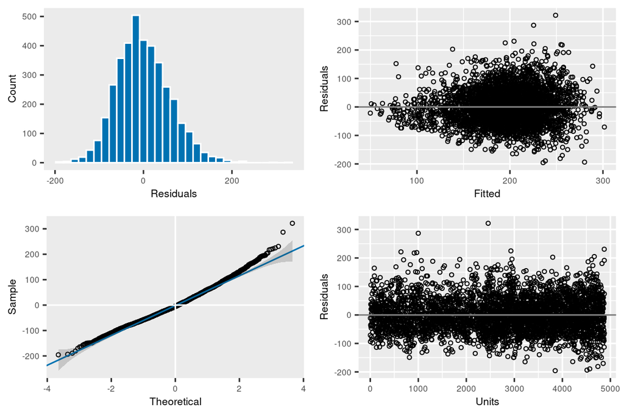

```r
# Factors
fs$REP<-as.factor(fs$REP)
fs$FEMALE<-as.factor(fs$FEMALE)
fs$MALE<-as.factor(fs$MALE)
fs$FAMILY<-as.factor(fs$FAMILY)

#table(fs$FAMILY,fs$REP) # complete block desing
#table(fs$MALE, fs$FEMALE) # partial diallel

# Analysis Full-Sib - Two additive terms
FSIB<-asreml(fixed=YIELD~REP,
             random=~FEMALE+MALE+FAMILY,data=fs)
plot(FSIB)
```

```r
summary(FSIB)$varcomp
```

```
##         component std.error   z.ratio bound %ch
## FEMALE   295.8593 127.37167  2.322803     P 0.0
## MALE     315.6228 138.32385  2.281767     P 0.1
## FAMILY   961.3243 158.34259  6.071167     P 0.0
## units!R 3816.3749  89.31128 42.731165     P 0.0
```

```r
# Select the parentes
pred.MALE<-predict(FSIB,classify="MALE",sed=TRUE)$pvals
pred.FEMALE<-predict(FSIB,classify="FEMALE",sed=TRUE)$pvals

# Ranking
as.data.frame(pred.FEMALE) %>%
  arrange(desc(predicted.value)) %>%
  head()
```

[output not shown]

```r
as.data.frame(pred.MALE) %>%
  arrange(desc(predicted.value)) %>%
  head()
```

```
##      MALE predicted.value std.error    status
## 1 PAR0060        210.7912  11.60847 Estimable
## 2 PAR0018        210.3832  15.07467 Estimable
## 3 PAR0008        209.2554  12.35393 Estimable
## 4 PAR0005        207.9697  13.00994 Estimable
## 5 PAR0020        206.5847  10.46859 Estimable
## 6 PAR0030        206.2246  15.08292 Estimable
```

```r
# h2
vpredict(FSIB,h2~ 2*(V1+V2)/(V1+V2+V3 +V4)) # additive
```

```
##     Estimate         SE
## h2 0.2269295 0.06403655
```

```r
vpredict(FSIB,h2~4*(V3)/(V1+V2+V3 +V4)) # dominance
```

```
##     Estimate        SE
## h2 0.7135216 0.1083072
```

```r
# Questions:
# i) Dominance effect seems more important that additive? Why?
```

# Conclusions

# References

- Isik et al., 2017. Genetic Data Analysis for Plant and Animal Breeding. [Book link](https://www.springer.com/gp/book/9783319551753)
- Hamilton, 2009. Population Genetics, 1st edition. [Book link](https://www.amazon.com/Population-Genetics-Matthew-Hamilton/dp/1405132779)
- Conner, J. and D. Hartl, A Primer of Ecological Genetics. [Book link](https://www.amazon.com/Primer-Ecological-Genetics-Jeffrey-Conner/dp/087893202X)
- Falconer and Mackay, 1996. Introduction to Quantitative Genetics. [Book link](https://www.amazon.com/Introduction-Quantitative-Genetics-Douglas-Falconer/dp/0582243025)

[figure not shown]